# beyond ggplot2, ggplot2 extensions

## online doc

http://exts.ggplot2.tidyverse.org

## plot Composition

### many approaches

- facet hacking
- gridExtra::grid.arrange()
- ggpubr::ggarrange()
- cowplot::plot_grid()
- patchwork

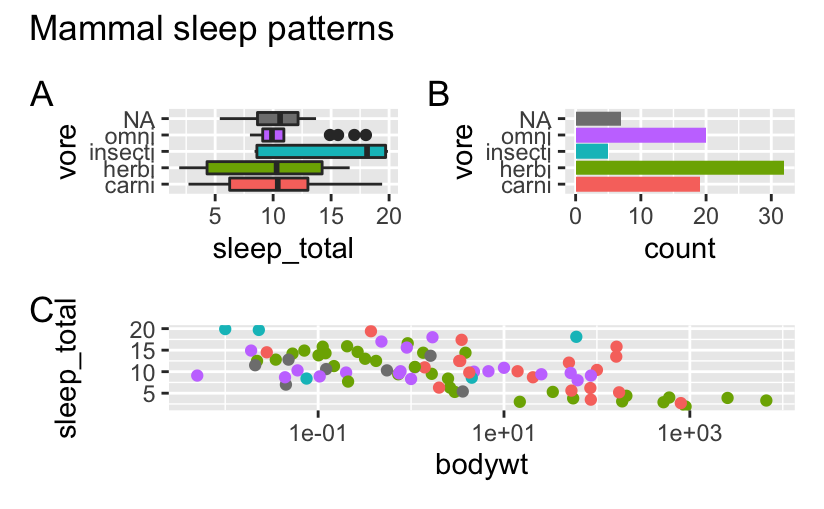

## Excercises

patchwork will assign the same amount of space to each plot by default, but this can be controlled with the `widths` and `heights` argument in `plot_layout()`

syntax - `plot_layout(heights=c(w1,w2,w3,...))`

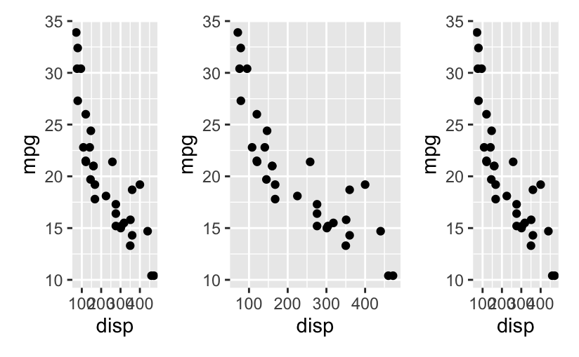

patchwork contains many features for fine tuning the layouts and annotation. very complex layouts can be obtained by providing a `design` argument in `plot_layout`.

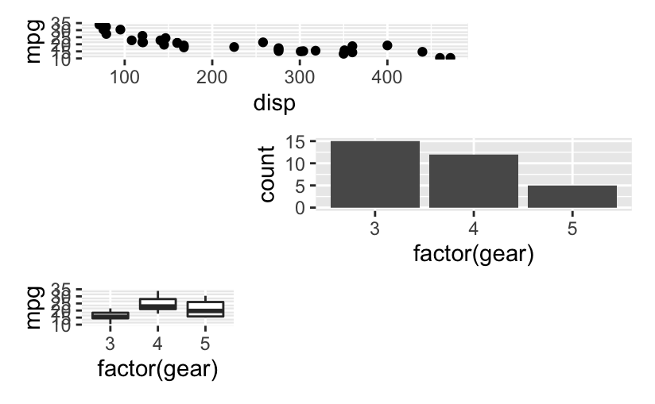